# Exercises: Deep Learning with R - Chapter 2

Guillaume Guénard

2022-04-13

# Data preparation

## Packages, directories, and sources

The following code loads the necessary `R` packages, resources directories, and sources:

```r
library(keras)
library(magrittr)
library(caret)
data_dir <- "../Data"
aux_dir <- "../Auxiliary"
aux_dir %>% file.path("Auxiliary.R") %>% source
```

## Loading the MNIST data set example

This code is for loading the MNIST handwritten digits example data set. To avoid having to download the data set each time the document is compiled, I have put the code to download and arrange the data and saves them into an `if(FALSE){...}` block. The pre-processed data are then simply loaded whenever the document is compiled.

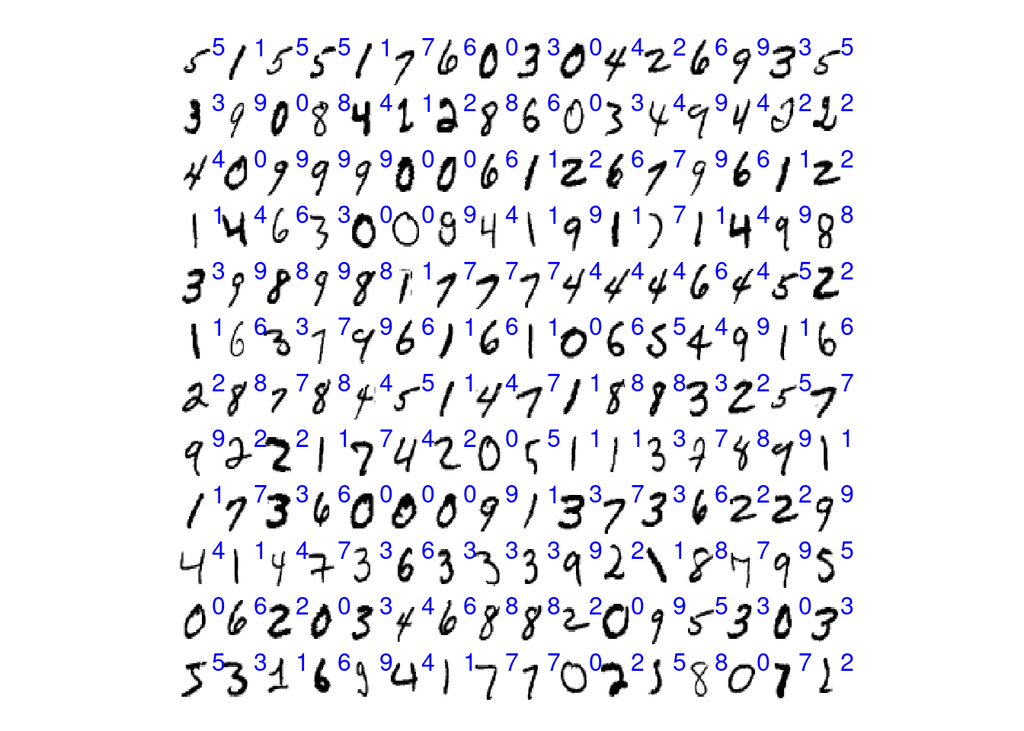

```r
if(FALSE){
  mnist <- dataset_mnist()
  train_images <- mnist$train$x
  train_labels <- mnist$train$y
  test_images <- mnist$test$x
  test_labels <- mnist$test$y
  rm(mnist)
  save(
    train_images, train_labels, test_images, test_labels,
    file = data_dir %>% file.path("mnist.rda")
  )
} else
  load(file = data_dir %>% file.path("mnist.rda"))

plot_tile(x=train_images, y=train_labels, n=16L, m=12L)
```

The last code line calls a custom plotting function, defined in the sources, and that allows one to plot a tile of digit images together with their labels. The numbers of columns and rows of digits that are displayed are controlled by arguments `n` and `m`, respectively.

To plot a given digit, it is also possible to convert the corresponding slice (a matrix) into a color raster using function `as.raster` and plot it as follows:

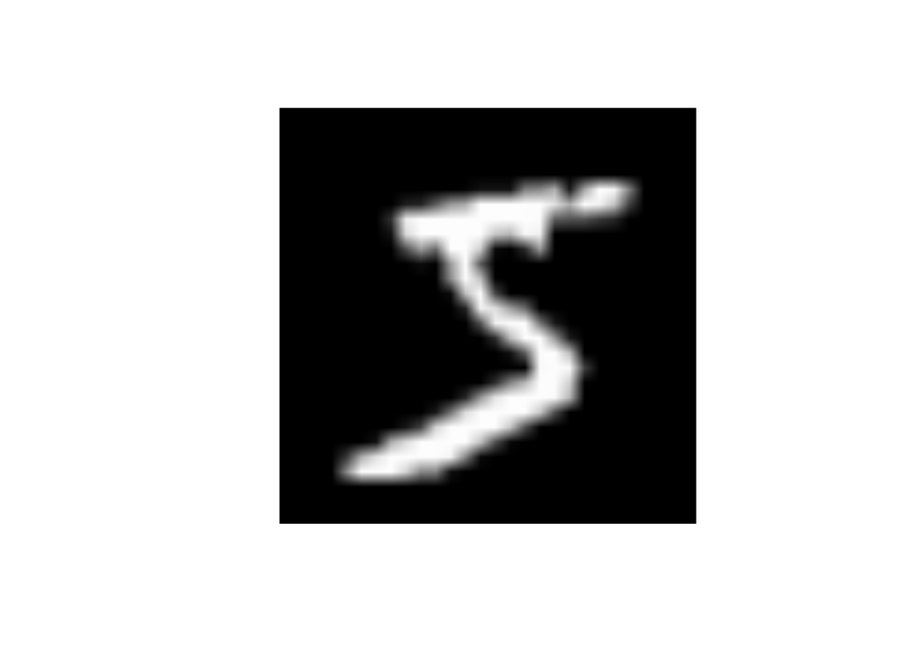

```r
train_images[1L,,] %>% as.raster(max=255) %>% plot
```

## Reshaping the array

The image data set is a 3-d array (images,width,height) of grayscale values. To prepare the data for training we convert the 3-d arrays into matrices by reshaping width and height into a single dimension (i.e., 28x28 images are flattened into length 784 vectors). Then, we convert the grayscale values from integers ranging between 0 to 255 into floating point values ranging between 0 and 1. Here, we need function `reticulate::array_reshape()` because the images are stored using column-major ordering, which is customarily used for storing data in `R` (see, `help("array_reshape",package="reticulate")` for details).

```r
train_images %<>% array_reshape(c(nrow(.), 28L*28L))
test_images %<>% array_reshape(c(nrow(.), 28L*28L))
```

Changing the scaling of the values into the 0-1 interval:

```r
train_images %<>% {./255}
test_images %<>% {./255}
```

Changing the coding of the label to categorical (binary) coding:

```r
train_labels %<>% to_categorical(10)
```

```
## Loaded Tensorflow version 2.8.0
```

```r
test_labels %<>% to_categorical(10)
```

Instead of single vector of integer, we now have a binary matrix:

```r
train_labels %>% head
```

[output not shown]

# Keras sequential model

Perhaps the simplest type of ANN is a sequential model whereby a single input layers feeds a chain of hidden layers culminating into a single output layer. This type of ANN is implemented using function `keras_model_sequential` as follows:

```r
keras_model_sequential() %>%
  layer_dense(
    input_shape = c(28L*28L),
    units = 256,
    activation = 'relu',
    name = "dense_1"
  ) %>%
  layer_dense(
    units = 10,
    activation = 'softmax',
    name = "output"
  ) -> ann_model
```

[output not shown]

The resulting model (`ann_model`) has a dense hidden layer with $256$ nodes. Because it inherits from `keras_model_sequential()` rather than an explicit upstream layer, function `layer_dense` needs to be provided its input shape using argument `input_shape`. The $28 \times 28$ images matrices were vectorized into length $784$ vectors, and thus the input shape is `c(784)`. The output of the first layer has activation function `'relu'`, which is a simple defined-by-parts non-linear function returning positive values unchanged and $0$ for the negative values:
$$RELU(x) =
\left\{
\begin{array}{lr}
x, & \text{if } x > 0\\
0, & \text{if } x \leq 0
\end{array}
\right\}$$
The output of the dense layer is fed directly into a second dense layer with a softmax output. The softmax function outputs the probability of different outcomes among the complete set of possible outcomes for a given problem. Here we have 10 digits, and thus the softmax will output 10 probabilities summing to $1$ for each image. Each probability is that of the image being associated with a particular label according to the model. The softmax function is defined as follows:
$$\text{softmax}(x_i) = {\text{e}^{x_i} \over \sum_{\forall j}
\text{e}^{x_j}}$$

## Compiling and training the model

Before being trained, the model first needs to be compiled as follows:

```r
ann_model %>%
  compile(
    loss = 'categorical_crossentropy',
    optimizer = optimizer_rmsprop(),
    metrics = c('accuracy')
  )
```

Argument `loss` is a textual variable specifying the loss function to be used for training the model. Argument `optimizer` specified the optimizer used to train the model (namely, to perform the gradient descent of the loss function over the model weights). Argument `metrics` specifies the metrics to estimate the model success (here: ‘accuracy’, which means the proportion of the labels that are correctly called).

The model is then fit to the training data as follows:

```r
ann_model %>%
  fit(
    train_images,
    train_labels,
    epochs = 60,
    batch_size = 120,
    validation_split = 0.2
  ) -> history
```

Its training history is plotted as follows:

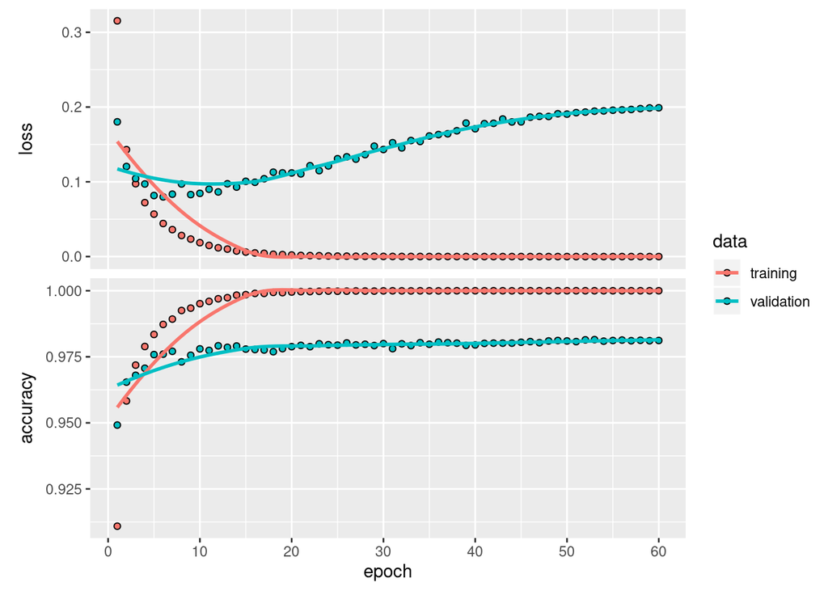

```r
history %>% plot
```

The fitted model (i.e., its structure, weights, and optimizer state) can be saved to the hdf5 format and then loaded as follows:

```r
ann_model %>%
  save_model_hdf5(
    filepath = "my_model.h5",
    overwrite = TRUE,
    include_optimizer = TRUE
  )
load_model_hdf5("my_model.h5") -> ann_model
```

Also, its is possible to save the model structure as a JSON string as follows:

```r
ann_model %>% model_to_json -> json_string
json_string %>% cat(file="my_model.json")
```

The JSON string will not save the model weights. The latter can be saved as an hdf5 file as follows:

```r
ann_model %>%
  save_model_weights_hdf5(
    filepath = "my_model_weights.h5",
    overwrite = TRUE
  )
```

The model can be loaded from these storage files as follows:

```r
model_from_json(json_string) -> model0
model0 %>% load_model_weights_hdf5('my_model_weights.h5')
```

## Evaluating the model’s out-of-the-sample accuracy

The model’s performance metrics are evaluated from the test images and labels as follows:

```r
ann_model %>%
  evaluate(
    test_images,
    test_labels
  ) -> metrics
```

```
##      loss  accuracy
## 0.1740658 0.9815000
```

One obtains the model’s predicted test labels as follows:

```r
ann_model %>%
  predict(test_images) %>%
  apply(1L, function(x) which.max(x) - 1L) %>%
  as.factor -> fitted_labels
```

The confusion matrix is obtained as follows:

```r
test_labels %>%
  apply(1L, function(x) which.max(x) - 1L) %>%
  as.factor -> reference_labels
fitted_labels %>%
  confusionMatrix(
    reference_labels
  ) -> cmat
cmat
```

```
## Confusion Matrix and Statistics
##
##           Reference
## Prediction    0    1    2    3    4    5    6    7    8    9
##          0  969    0    1    0    2    2    3    1    2    2
##          1    1 1127    0    0    0    1    2    3    1    2
##          2    1    3 1010    3    0    0    2    8    3    0
##          3    0    0    3  994    1    8    1    2    4    3
##          4    1    0    1    0  962    1    3    1    4    4
##          5    2    1    0    3    0  869    3    0    3    4
##          6    3    2    2    0    5    4  943    0    1    0
##          7    1    1    8    4    1    0    1 1005    4    4
##          8    1    1    6    3    2    3    0    4  947    1
##          9    1    0    1    3    9    4    0    4    5  989
##
## Overall Statistics
##
##                Accuracy : 0.9815
##                  95% CI : (0.9787, 0.9841)
##     No Information Rate : 0.1135
##     P-Value [Acc > NIR] : < 2.2e-16
##
##                   Kappa : 0.9794
##
##  Mcnemar's Test P-Value : NA
##
## Statistics by Class:
##
##                      Class: 0 Class: 1 Class: 2 Class: 3 Class: 4 Class: 5
## Sensitivity            0.9888   0.9930   0.9787   0.9842   0.9796   0.9742
## Specificity            0.9986   0.9989   0.9978   0.9976   0.9983   0.9982
## Pos Pred Value         0.9868   0.9912   0.9806   0.9783   0.9846   0.9819
## Neg Pred Value         0.9988   0.9991   0.9975   0.9982   0.9978   0.9975
## Prevalence             0.0980   0.1135   0.1032   0.1010   0.0982   0.0892
## Detection Rate         0.0969   0.1127   0.1010   0.0994   0.0962   0.0869
## Detection Prevalence   0.0982   0.1137   0.1030   0.1016   0.0977   0.0885
## Balanced Accuracy      0.9937   0.9959   0.9882   0.9909   0.9890   0.9862
##                      Class: 6 Class: 7 Class: 8 Class: 9
## Sensitivity            0.9843   0.9776   0.9723   0.9802
## Specificity            0.9981   0.9973   0.9977   0.9970
## Pos Pred Value         0.9823   0.9767   0.9783   0.9734
## Neg Pred Value         0.9983   0.9974   0.9970   0.9978
## Prevalence             0.0958   0.1028   0.0974   0.1009
## Detection Rate         0.0943   0.1005   0.0947   0.0989
## Detection Prevalence   0.0960   0.1029   0.0968   0.1016
## Balanced Accuracy      0.9912   0.9875   0.9850   0.9886
```

Some errors are more common than others. For instances, digits 5 was taken to be a 3, and 7 were taken to be 2 more often than 4 were confused for 1. This is not surprising from general knowledge.